# Patel_D_10

Cereal Data set

we will first work with the cereal data set and perform various tasks on it

```r
require(readxl)
# Import the excel file into a data frame
cereal_data <- read_xls("cereal_data__for_slide_deck_.xls", sheet = 2)
cereal_data
```

| Product | Cereal Name | Manufacturer | Calories | Sodium | Fiber | Carbs | Sugars | Shelf | X__1 | X__2 |
| --- | --- | --- | --- | --- | --- | --- | --- | --- | --- | --- |
| 1 | 100% Bran | Nabisco | 70 | 130 | 10.0 | 5.0 | 6 | 3 | NA | NA |
| 2 | AlI-Bran | Kellogg | 70 | 260 | 9.0 | 7.0 | 5 | 3 | 5 | NA |
| 3 | All-Bran w/Extra Fiber | Kellogg | 50 | 140 | 14.0 | 8.0 | 0 | 3 | NA | NA |
| 4 | Almond Delight | Ralston Purina | 110 | 200 | 1.0 | 14.0 | 8 | 3 | NA | NA |
| 5 | Apple Cinn Cheerios | General Mills | 110 | 180 | 1.5 | 10.5 | 10 | 1 | NA | NA |
| 6 | Apple Jacks | Kellogg | 110 | 125 | 1.0 | 11.0 | 14 | 2 | NA | NA |
| 7 | Basic 4 | General Mills | 130 | 210 | 2.0 | 18.0 | 8 | 3 | NA | NA |
| 8 | Bran Chex | Ralston Purina | 90 | 200 | 4.0 | 15.0 | 6 | 1 | NA | NA |
| 9 | Bran Flakes | Post | 90 | 210 | 5.0 | 13.0 | 5 | 3 | NA | NA |
| 10 | Cap'n'Crunch | Quaker | 120 | 220 | 0.0 | 12.0 | 12 | 2 | NA | NA |

[output cut: 57 more lines]

1. Using the Cereal Data set, determine the mean, median, range, mode, and standard deviation of the carbs and fiber variables

```r
library(dplyr)
carb_mean <- mean(cereal_data$Carbs)
fiber_mean <- mean(cereal_data$Fiber)
sprintf("The mean for carbs: %g", carb_mean)
```

```
[1] "The mean for carbs: 14.7687"
```

```r
sprintf("The mean for fiber: %g", fiber_mean)
```

```
[1] "The mean for fiber: 2.18657"
```

```r
carb_median <- median(cereal_data$Carbs)
fiber_median <- median(cereal_data$Fiber)
sprintf("The median for carbs: %g", carb_median)
```

```
[1] "The median for carbs: 14"
```

```r
sprintf("The median for fiber: %g", fiber_median)
```

```
[1] "The median for fiber: 1.5"
```

```r
carb_range <- range(cereal_data$Carbs)
fiber_range <- range(cereal_data$Fiber)
sprintf("The range for carbs: %s - %s", carb_range[1], carb_range[2])
```

```
[1] "The range for carbs: 5 - 23"
```

```r
sprintf("The range for fiber: %s - %s", fiber_range[1], fiber_range[2])
```

```
[1] "The range for fiber: 0 - 14"
```

```r
carb_mode <- as.numeric(names(table(cereal_data$Carbs))[1])
fiber_mode <- as.numeric(names(table(cereal_data$Fiber))[1])
sprintf("The mode for carbs: %g", carb_mode)
```

[output not shown]

```r
sprintf("The mode for fiber: %g", fiber_mode)
```

```
[1] "The mode for fiber: 0"
```

```r
carb_std <- sd(cereal_data$Carbs)
fiber_std <- sd(cereal_data$Fiber)
sprintf("The standard deviation for carbs: %g", carb_std)
```

```
[1] "The standard deviation for carbs: 3.85959"
```

```r
sprintf("The standard deviation for fiber: %g", fiber_std)
```

```
[1] "The standard deviation for fiber: 2.50581"
```

2. Histograms for calories and sugar variables

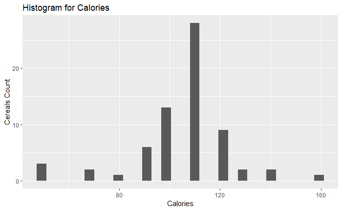

```r
library(ggplot2)
ggplot(data = cereal_data, aes(cereal_data$Calories)) +  geom_histogram() +
  labs(title="Histogram for Calories") +
  labs(x="Calories", y="Cereals Count")
```

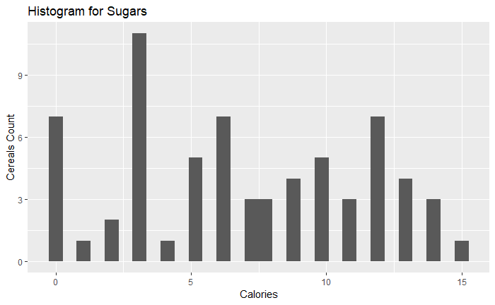

```r
library(ggplot2)
ggplot(data = cereal_data, aes(cereal_data$Sugars)) +  geom_histogram() +
  labs(title="Histogram for Sugars") +
  labs(x="Calories", y="Cereals Count")
```

3. Scatterplots of the Carbs and Fiber variables

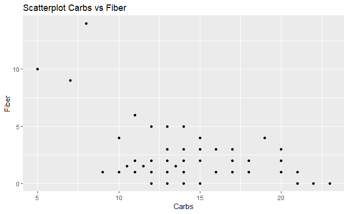

```r
ggplot(data = cereal_data, aes(x = Carbs, y = Fiber)) + geom_point() +
  labs(title="Scatterplot Carbs vs Fiber")
```

4. Pearson Moment and the Spearman Rank correlation coefficients for the calories and fiber variables

```r
# The Pearson Moment Formula:
# z(k) = k - mean(k) / std(k)
# Pearson Moment = sum(1, n, z(x) * z(y)) / n - 1
cal_fib_moment <- cor(cereal_data$Calories, cereal_data$Fiber)
cal_fib_moment
```

```
[1] -0.3652843
```

There is a negative correlation between the amount of calories and fiber in data. As calories rise fiber falls.

```r
# Spearman Rank Correlation
cal_fib_rho <- cor(cereal_data$Calories, cereal_data$Fiber, method = "spearman")
cal_fib_rho
```

```
[1] -0.2229893
```

The speaman coefficient also shows a negative correlation. Calories up = fiber down

Grades Data Set

```r
require(openxlsx)
# Import the data for fall and spring into seperate data frames
fall_grades_data <- read.xlsx("workshop_data_set__grades_2018.xlsx", sheet = 1, startRow = 2)
spring_grades_data <- read.xlsx("workshop_data_set__grades_2018.xlsx", sheet = 2, startRow = 3)
head(fall_grades_data)
```

|  | Record | Section | Instructor | Grade | Score | TQ1 | TQ2 | TQ3 | TQ4 | TQ5 | TQ6 | TQ7 | TQ8 | TQ9 | TQ10 | TQ11 | TQ12 | TQ13 | TQ14 | TQ15 | TQ17 | TQ.Avg | A2 | A3 | A4 | A5 | A6 | A7 | A8 | … |
| --- | --- | --- | --- | --- | --- | --- | --- | --- | --- | --- | --- | --- | --- | --- | --- | --- | --- | --- | --- | --- | --- | --- | --- | --- | --- | --- | --- | --- | --- | --- |
| 1 | 1 | 3 | Allan | A | 98.07333 | 100.00 | 100 | 94 | 100 | 100 | 100 | 100 | 100 | 90 | 100 | 100 | 100 | 80.5 | 75 | 100 | 100 | 95.96667 | 94 | 95 | 100 | 98 | 90 | 98 | 100 | … |
| 2 | 2 | 3 | Allan | A | 99.09083 | 100.00 | 90 | 90 | 100 | 91 | 95 | 100 | 100 | 80 | 100 | 100 | 100 | 80 | 70 | 100 | 100 | 93.06667 | 99 | 93 | 100 | 100 | 100 | 98 | 100 | … |
| 3 | 3 | 6 | Denison | A | 100.24917 | 91.45 | 100 | 100 | 100 | 91 | 95 | 100 | 100 | 100 | 100 | 100 | 100 | 100 | 80 | 100 | 100 | 97.73333 | 98 | 95 | 95 | 98 | 95 | 100 | 100 | … |
| 4 | 4 | 3 | Allan | A | 98.04833 | 80.00 | 90 | 100 | 100 | 91 | 95 | 86 | 100 | 80 | 100 | 100 | 90 | 80 | 95 | 80 | 100 | 92.46667 | 84 | 95 | 100 | 100 | 100 | 100 | 100 | … |
| 5 | 5 | 4 | Denison | A | 99.68250 | 100.00 | 100 | 100 | 100 | 100 | 90 | 100 | 100 | 90 | 100 | 100 | 100 | 93.5 | 70 | 50 | 100 | 92.90000 | 98 | 100 | 100 | 100 | 98 | 100 | 100 | … |
| 6 | 6 | 4 | Denison | A- | 91.11500 | 94.30 | 100 | 90 | 100 | 91 | 90 | 93 | 100 | 0 | 100 | 90 | 90 | 80.5 | 95 | 0 | 100 | 81.30000 | 100 | 90 | 100 | 93 | 92 | 96 | 100 | … |

```r
print(head(spring_grades_data))
```

|  | Record | Section | Instructor | Grade | Score | TQ2 | TQ3 | TQ4 | TQ5 | TQ6 | TQ11 | A2 | A3 | A4 | A5 | A6 | A7 | A8 | A9 | A12 | A13 | A14 | A15 | A16 | Project | Excel.Quiz | Excel.Test | Access.Quiz | Access.Test | … |
| --- | --- | --- | --- | --- | --- | --- | --- | --- | --- | --- | --- | --- | --- | --- | --- | --- | --- | --- | --- | --- | --- | --- | --- | --- | --- | --- | --- | --- | --- | --- |
| 1 | 1 | 1 | Smith | A | 100.51786 | 100 | 100 | 100 | 100 | 100 | 100 | 100 | 99 | 120 | 100 | 100 | 100 | 100 | NA | 100 | 100 | 95 | 115 | 100 | 100 | 90 | 100 | 100 | 100 | … |
| 2 | 2 | 1 | Smith | B+ | 87.66071 | 80 | 80 | 100 | 90 | 100 | 90 | 92 | 90 | 115 | 100 | 98 | 100 | 100 | NA | 95 | 100 | 100 | 100 | 97 | 90 | 90 | 80 | 80 | 85 | … |
| 3 | 3 | 1 | Smith | A | 96.02381 | 100 | 80 | 100 | 80 | 100 | 100 | 100 | 99 | 120 | 100 | 100 | 100 | 100 | NA | 100 | 100 | 100 | 115 | 100 | 100 | 95 | 85 | 100 | 100 | … |
| 4 | 4 | 1 | Smith | A | 103.03571 | 100 | 100 | 100 | 100 | 55 | 100 | 100 | 100 | 120 | 100 | 100 | 100 | 100 | 100 | 100 | 100 | 100 | 115 | 100 | 100 | 90 | 100 | 110 | 100 | … |
| 5 | 5 | 1 | Smith | C+ | 77.64881 | 50 | 40 | 20 | 20 | 10 | 90 | 92 | 99 | 120 | 98 | 95 | 99 | 98 | NA | 100 | 80 | 100 | 105 | 75 | 70 | 45 | 65 | 0 | 85 | … |
| 6 | 6 | 1 | Smith | C- | 62.92262 | 100 | 80 | 100 | 70 | 70 | 100 | 99 | 83 | 50 | 90 | NA | 100 | NA | NA | 95 | 90 | NA | NA | NA | NA | 45 | NA | 40 | NA | … |

1. Using the Grades Data set, determine the mean, median, range, mode, and standard deviation of the Score variable for Fall and Spring.

```r
fall_mean <- mean(fall_grades_data$Score)
spring_mean <- mean(spring_grades_data$Score)
sprintf("The mean for fall: %g", fall_mean)
```

```
[1] "The mean for fall: 94.4616"
```

```r
sprintf("The mean for spring: %g", spring_mean)
```

```
[1] "The mean for spring: 89.1225"
```

```r
fall_median <- median(fall_grades_data$Score)
spring_median <- median(spring_grades_data$Score)
sprintf("The median for fall: %g", fall_median)
```

```
[1] "The median for fall: 96.9578"
```

```r
sprintf("The median for spring: %g", spring_median)
```

```
[1] "The median for spring: 93.8631"
```

```r
fall_range <- range(fall_grades_data$Score)
spring_range <- range(spring_grades_data$Score)
sprintf("The range for fall: %s - %s", fall_range[1], fall_range[2])
```

```
[1] "The range for fall: 19.4854166666667 - 102.635833333333"
```

```r
sprintf("The range for fall: %s - %s", spring_range[1], spring_range[2])
```

```
[1] "The range for fall: 10.9464285714286 - 103.035714285714"
```

```r
fall_mode <- as.numeric(names(table(fall_grades_data$Score))[1])
spring_mode <- as.numeric(names(table(spring_grades_data$Score))[1])
sprintf("The mode for fall: %g", fall_mode)
```

[output not shown]

```r
sprintf("The mode for spring: %g", spring_mode)
```

[output not shown]

```r
fall_std <- sd(fall_grades_data$Score)
spring_std <- sd(spring_grades_data$Score)
sprintf("The standard deviation for fall: %g", fall_std)
```

```
[1] "The standard deviation for fall: 8.69194"
```

```r
sprintf("The standard deviation for spring: %g", spring_std)
```

```
[1] "The standard deviation for spring: 13.2544"
```

2. Pearson Moment and the Spearman Rank correlation coefficients for the fall score and excel quiz variables

```r
# The Pearson Moment Formula:
# z(k) = k - mean(k) / std(k)
# Pearson Moment = sum(1, n, z(x) * z(y)) / n - 1
score_quiz_moment <- cor.test(fall_grades_data$Score, fall_grades_data$Excel.Quiz)
score_quiz_moment
```

```
    Pearson's product-moment correlation

data:  fall_grades_data$Score and fall_grades_data$Excel.Quiz
t = 13.76, df = 361, p-value < 2.2e-16
alternative hypothesis: true correlation is not equal to 0
95 percent confidence interval:
 0.5146843 0.6502200
sample estimates:
      cor
0.5865436
```

```r
# Spearman Rank Correlation
score_quiz_rho <- cor.test(fall_grades_data$Score, fall_grades_data$Excel.Quiz, method = "spearman")
```

```
Cannot compute exact p-value with ties
```

```r
score_quiz_rho
```

```
    Spearman's rank correlation rho

data:  fall_grades_data$Score and fall_grades_data$Excel.Quiz
S = 3189400, p-value < 2.2e-16
alternative hypothesis: true rho is not equal to 0
sample estimates:
      rho
0.5999248
```

The speaman coefficient also shows a positive correlation. Score up = Excel Quiz up, the pvalue is small and so its is statistically significant

3. Scatter plot using the Fall score and the Excel Quiz variable

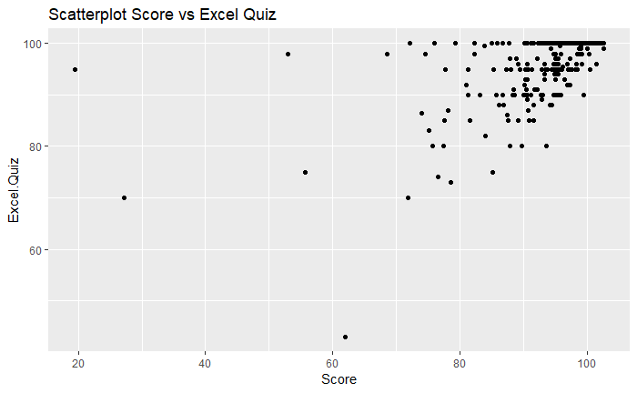

```r
ggplot(data = fall_grades_data, aes(x = Score, y = Excel.Quiz)) + geom_point() +
  labs(title="Scatterplot Score vs Excel Quiz")
```

```r
binning_frame <- data.frame(bins=integer(1000))
for(i in 1:1000){
binning_frame[i, "bins"] <- mean(sample(fall_grades_data$Score,round(length(fall_grades_data) * .2)))
}
binning_frame
```

| bins |
| --- |
| 92.48627 |
| 97.70037 |
| 96.16114 |
| 93.96363 |
| 95.37775 |
| 95.07960 |
| 94.48722 |
| 96.91352 |
| 83.71994 |
| 96.27784 |

[output cut: 990 more lines]

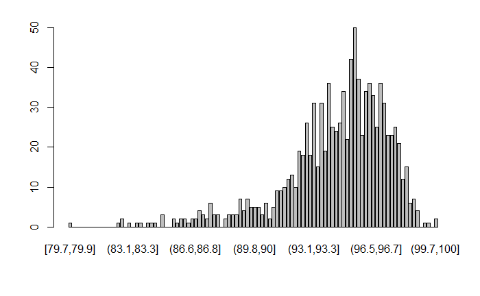

```r
bins <- cut(binning_frame[, "bins"], 100, include.lowest = TRUE)
plot(bins)
```

From this plot we can see the distribution is skewed left and most scores are concentrated in the 93-96 range.